# Topic 12

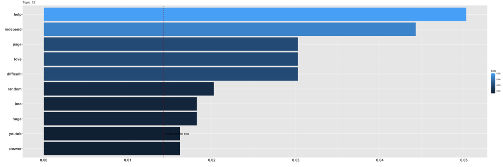

On interpreting beta: the term has a beta probability of being generated from the particular topic.

Values below are gamma : An estimated proportion of words from that document that are generated from that topic.

**Text Record Number: 534** gamma: 12 % likelihood of this document (based on its words) in this topic

**I claim you’ll never have true hand independence. It’s not a singular skill you learn. Every piece will bring a new independence difficulty. More complex pieces will have more difficult independence challenges, even if all the pieces you played before that were perfectly fine from an independence perspective.**

**Text Record Number: 543** gamma: 12 % likelihood of this document (based on its words) in this topic

**It depends on a lot of factors - piece difficulty, section difficulty, your experience level, fingering you’ve chosen etc. etc.

More generally, here are some pieces of advice I would give:

- If you can’t play it slowly, you won’t be able to play it quickly. Always get comfortable (i.e. a couple days of consistently accurate practice sessions) with slow practice before speeding up.
- Similarly, if you can’t play it hands separately, you probably will struggle to play it hands together.
- Count like crazy! It really helps to work out the placement of notes in relation to one another.
- Try breaking down your notes into how many quavers (8th notes) they are worth. This is called subdividing (i.e. instead of counting
  $$1, 2, 3, 4$$
  , with each beat representing one crotchet/quarter note, try counting
  $$1 and 2 and 3 and 4 and$$
  , with everything representing a half beat instead). There are lots of videos on YouTube on subdividing, if it’s a concept you aren’t familiar with.

Hope that helps! It is hard to develop hand independence, but you do get there with experience so make sure you’re playing pieces of your level too. Obviously challenge yourself and play what you enjoy, but make sure you’re also playing some pieces you can get through relatively quickly in order to gain experience of the feeling of hand independence in a range of contexts.**

**Text Record Number: 523** gamma: 12 % likelihood of this document (based on its words) in this topic

**I believe to a certain extent it is a skill that can be acquired, but only ever in particular “styles”. Allow me to elaborate; Someone who is really good at improv can just tickle the keys in a way that allows them to whip up something on the spot. How do they do this if there is no such thing as “hand independence”? They aren’t referencing any written music, they aren’t practicing an improvised piece over and over again until they can commit it to muscle memory. They’re just playing something, plucked right out of their brain, right there on the spot. Piano streamers do stuff like this all the time.

In light of this, I would say it depends on what one would consider “hand independence”. In the most literal sense, I believe you are correct, there is no such thing as genuine hand independence. So how does that explain really good improv? Well, another way to look at hand independence is to define it as the ability to recall specific patterns from muscle memory, and apply them without thinking about it. Someone who is really good at improv will obviously have a specific style in how they play. That style comes from what patterns they have accumulated in their muscle memory, and which patterns they wish to use for whatever idea they are trying to put into an improv performance. In this context, it is absolutely a skill that can be acquired, and can be learned by anybody.**

**Text Record Number: 487** gamma: 12 % likelihood of this document (based on its words) in this topic

**thanks, I’m inclining towards buying a used All in one PC, as opposed to a small tablet . I don’t anticipate needing much portability, will play at home almost always. It’s good to know that the bigger screen may help me reading music!!!**

**Text Record Number: 988** gamma: 12 % likelihood of this document (based on its words) in this topic

**As much as I advocate for weaning yourself off of looking at your hands, I don’t think this is a good approach to developing the skill.

For one, I can’t think of any way this wouldn’t inhibit or at least distract from the motions your hands need to make. If I was trying to play most things I play with my hands covered in a cloth, the cloth would become a jumbled, wadded mess before falling off or getting under my fingers.

Aside from the actual impracticality of it, there are plenty of pedagogical reasons I don’t think it’s the best.

My advice is for people to definitely try to play without looking, but don’t do it at the expense of lots of mistakes because then you’re just reinforcing “guess” work in your muscle memory.

My advice would be to follow these steps.

1. Absolutely look at your hands and make sure you’re not making technical mistakes.
2. Try looking up (preferably at the sheet of music to reinforce association between the notes on the page and what you are playing) but be keenly aware of your hands in your periphery. If you need to glance down do so ONLY with your eyes, not by moving your neck.
3. Try to NOT look at all. Stare at the page and no glancing. For purely technical work you can try just straight up closing your eyes. I often find this actually makes it easier. Try to visualize what your hands are doing. You KNOW what the keyboard looks like and you’ve seen your hands do this… You know what they should be doing, so imagine you are seeing them even if you aren’t seeing them.

Often reviewing old pieces you’ve played but forcing yourself to do them without looking can work. Once again you KNOW you can play them, so can your hands know what to do… so now do it without looking confident in the knowledge that you DO know how to play it already.

Some weird miscellaneous strategies to try for hashing out technical exercises without looking.

- Skip step 2 above and instead keep your head facing the keys but close your eyes and move to step 3. As strange as it is, little things like your head being in the same position (looking down) can affect the accuracy of your repetitions. Getting accurate with your eyes closed but *facing* the keys first and *then* trying to move your gaze up (eyes closed) can help this.

It’s super fucking weird, but it absolutely can help (I *still* find myself doing this, particularly with guitar which I’m less competent at). It just makes visualizing easier if you’re actually “looking” even if you’re not seeing.

- For things like stride (or any other large jumps) I’ve found it useful to LOOK, then *make the jump*, but then close my eyes. Then I gradually adjust when my eye close. I start with “when my hand reaches the desired position, but before I strike the keys” and then sooner and sooner… “look at the position, but close my eyes before jumping to that position.”
- Another useful thing to be aware of it feeling black keys and learning topography. Often for large jumps I will start by going blind for them, but I can feel the distance I’m aiming at before I hit it. I essentially check before committing.

Early on all of these will force you to slow down, but eventually you’ll get confident and be able to speed up.**

**Text Record Number: 649** gamma: 12 % likelihood of this document (based on its words) in this topic

**I’ve been looking into a better solution for what I do at the moment too (carrying around 2 very heavy folders!) I’m after something much more portable. At the moment, I’m looking at having all my sheet music on my phone in pdf format and using a portable monitor (probably around 21"). I will use MobileSheets to organise all the pdfs on the phone. Hope that helps 👍**

**Text Record Number: 1167** gamma: 12 % likelihood of this document (based on its words) in this topic

**I think what you’ve done so far is awesome. Really solid playing. I think to take your performance forwards I’d look to start adding some rubato and more dynamic contrast, with some clearer phrasing too. All of this will help it to sound more expressive - but don’t get me wrong, the first step with any piece is to get the notes down and you’ve definitely started to get that.

It’s a beautiful piece of music and Yiruma has plenty of other pieces worth checking out if you liked this one.

Edit: I’d just add one more thing too - at the start be sure to count those rests. A common issue I often see with people recording and/or performing is rushing the rests because it can feel uncomfortable (be it conscious or not), but just let those rests breath particularly at the start.**